# General impact of macro-nutrients in the calories content of food

## DATASET OVERVIEW

### Introduce the dataset : Food Composition Database.

> It contains data for various types of food including the amounts of different nutrients found in the foods:

### Explanations of the columns

- Vitamin A: 1 IU is the biological equivalent of 0.3 mcg retinol,
- Vitamin A measured in RAE, means the amount of vitamin A that we can obtain from a certain amount of calories.
- Retinol (vitamin A)
- riboflavin (vitamin B2)
- Niacin (b coplext E),
- Pantothenic Acid(b5 E)
- Thiamin(B1 E)
- lipids any of a class of organic compounds that are fatty acids or their derivatives and are insoluble in water but soluble * in organic solvents.
- Monounsaturated fats are healthy fats;
- Ash refers to any inorganic material, such as minerals, present in food. It's called ash because it's residue that remains after heating removes water and organic material such as fat and protein.
- Fiber is a type of carbohydrate that the body can’t digest
- The phytochemicals include: Carotene,Cryptoxanthin, Lutein and Zeaxanthin, Lycopene,
- lipids Cholesterol
- Total Lipid = Cholesterol + fats
- Kilocalories = energy foods
- Choline :A water-soluble vitamin. Measured in milligrams (mg).
- Category : general category of food that this item belongs to.
- Description : A full description of this food item, including its category and some sub categories.
- Nutrient Data Bank Number : A unique ID for this food item.
- The Data set also contains mirco-nutrients like MINERALS AND VITAMINS, etc

Source: https://www.kaggle.com/datasets/trolukovich/nutritional-values-for-common-foods-and-products/download?datasetVersionNumber=1

## Preliminary Wrangling

```python
# import all packages and set plots to be embedded inline
import numpy as np
import pandas as pd
import matplotlib.pyplot as plt
import seaborn as sb

%matplotlib inline

# suppress warnings from final output
import warnings
warnings.simplefilter("ignore")
```

```python
#read our dataset
nutrients_df = pd.read_csv('nutrition.csv')
```

```python
#get the first 05 rows
nutrients_df.head()
```

|  | Unnamed: 0 | name | serving_size | calories | total_fat | saturated_fat | cholesterol | sodium | choline | folate | ... | fat | saturated_fatty_acids | monounsaturated_fatty_acids | polyunsaturated_fatty_acids | fatty_acids_total_trans | alcohol | ash | caffeine | theobromine | water |
| --- | --- | --- | --- | --- | --- | --- | --- | --- | --- | --- | --- | --- | --- | --- | --- | --- | --- | --- | --- | --- | --- |
| 0 | 0 | Cornstarch | 100 g | 381 | 0.1g | NaN | 0 | 9.00 mg | 0.4 mg | 0.00 mcg | ... | 0.05 g | 0.009 g | 0.016 g | 0.025 g | 0.00 mg | 0.0 g | 0.09 g | 0.00 mg | 0.00 mg | 8.32 g |
| 1 | 1 | Nuts, pecans | 100 g | 691 | 72g | 6.2g | 0 | 0.00 mg | 40.5 mg | 22.00 mcg | ... | 71.97 g | 6.180 g | 40.801 g | 21.614 g | 0.00 mg | 0.0 g | 1.49 g | 0.00 mg | 0.00 mg | 3.52 g |
| 2 | 2 | Eggplant, raw | 100 g | 25 | 0.2g | NaN | 0 | 2.00 mg | 6.9 mg | 22.00 mcg | ... | 0.18 g | 0.034 g | 0.016 g | 0.076 g | 0.00 mg | 0.0 g | 0.66 g | 0.00 mg | 0.00 mg | 92.30 g |
| 3 | 3 | Teff, uncooked | 100 g | 367 | 2.4g | 0.4g | 0 | 12.00 mg | 13.1 mg | 0 | ... | 2.38 g | 0.449 g | 0.589 g | 1.071 g | 0 | 0 | 2.37 g | 0 | 0 | 8.82 g |
| 4 | 4 | Sherbet, orange | 100 g | 144 | 2g | 1.2g | 1mg | 46.00 mg | 7.7 mg | 4.00 mcg | ... | 2.00 g | 1.160 g | 0.530 g | 0.080 g | 1.00 mg | 0.0 g | 0.40 g | 0.00 mg | 0.00 mg | 66.10 g |

5 rows × 77 columns

```python
nutrients_df.columns
```

```
Index(['Unnamed: 0', 'name', 'serving_size', 'calories', 'total_fat',
       'saturated_fat', 'cholesterol', 'sodium', 'choline', 'folate',
       'folic_acid', 'niacin', 'pantothenic_acid', 'riboflavin', 'thiamin',
       'vitamin_a', 'vitamin_a_rae', 'carotene_alpha', 'carotene_beta',
       'cryptoxanthin_beta', 'lutein_zeaxanthin', 'lucopene', 'vitamin_b12',
       'vitamin_b6', 'vitamin_c', 'vitamin_d', 'vitamin_e', 'tocopherol_alpha',
       'vitamin_k', 'calcium', 'copper', 'irom', 'magnesium', 'manganese',
       'phosphorous', 'potassium', 'selenium', 'zink', 'protein', 'alanine',
       'arginine', 'aspartic_acid', 'cystine', 'glutamic_acid', 'glycine',
       'histidine', 'hydroxyproline', 'isoleucine', 'leucine', 'lysine',
       'methionine', 'phenylalanine', 'proline', 'serine', 'threonine',
       'tryptophan', 'tyrosine', 'valine', 'carbohydrate', 'fiber', 'sugars',
       'fructose', 'galactose', 'glucose', 'lactose', 'maltose', 'sucrose',
       'fat', 'saturated_fatty_acids', 'monounsaturated_fatty_acids',
       'polyunsaturated_fatty_acids', 'fatty_acids_total_trans', 'alcohol',
       'ash', 'caffeine', 'theobromine', 'water'],
      dtype='object')
```

```python
nutrients_df.shape
```

```
(8789, 77)
```

### What is the structure of your dataset?

> The data set is composed of 8789 food descriptions with 77 columns that can be easily engineered into vitamins, minerals, macronutrients, Ash, food groups:

### What is/are the main feature(s) of interest in your dataset?

> In this Data set, we wiil investigate the general impacts of macro-nutrients in the taotal calories content of food

### What features in the dataset do you think will help support your investigation into your feature(s) of interest?

> From the boilogical point of view, we should espect that fats should have the major effect on the total calories of food. while carbohydrate and protiens will have least.

> we also have data on the composition of these main nutrients that might help in our analyis: ie
> - total_fat(fats) :'saturated_fat', 'cholesterol', fat', 'saturated_fatty_acids', 'monounsaturated_fatty_acids','polyunsaturated_fatty_acids', 'fatty_acids_total_trans',
> - protiens: histidine, valine, isoleucine, leucine, phenylalanine, threonine, tryptophan, methionine, and lysine.
> - carbohydrate: 'sugars','fructose', 'galactose', 'glucose', 'lactose', 'maltose', 'sucrose'

```python
nutrients_df.info()
```

```
<class 'pandas.core.frame.DataFrame'>
RangeIndex: 8789 entries, 0 to 8788
Data columns (total 77 columns):
Unnamed: 0                     8789 non-null int64
name                           8789 non-null object
serving_size                   8789 non-null object
calories                       8789 non-null int64
total_fat                      8789 non-null object
saturated_fat                  7199 non-null object
cholesterol                    8789 non-null object
sodium                         8789 non-null object
choline                        8789 non-null object
folate                         8789 non-null object
folic_acid                     8789 non-null object
niacin                         8789 non-null object
pantothenic_acid               8789 non-null object
riboflavin                     8789 non-null object
thiamin                        8789 non-null object
vitamin_a                      8789 non-null object
vitamin_a_rae                  8789 non-null object
carotene_alpha                 8789 non-null object
carotene_beta                  8789 non-null object
cryptoxanthin_beta             8789 non-null object
lutein_zeaxanthin              8789 non-null object
lucopene                       8789 non-null int64
vitamin_b12                    8789 non-null object
vitamin_b6                     8789 non-null object
vitamin_c                      8789 non-null object
vitamin_d                      8789 non-null object
vitamin_e                      8789 non-null object
tocopherol_alpha               8789 non-null object
vitamin_k                      8789 non-null object
calcium                        8789 non-null object
copper                         8789 non-null object
irom                           8789 non-null object
magnesium                      8789 non-null object
manganese                      8789 non-null object
phosphorous                    8789 non-null object
potassium                      8789 non-null object
selenium                       8789 non-null object
```

[output cut: 27 more lines]

```
lactose                        8789 non-null object
maltose                        8789 non-null object
sucrose                        8789 non-null object
fat                            8789 non-null object
saturated_fatty_acids          8789 non-null object
monounsaturated_fatty_acids    8789 non-null object
polyunsaturated_fatty_acids    8789 non-null object
fatty_acids_total_trans        8789 non-null object
alcohol                        8789 non-null object
ash                            8789 non-null object
caffeine                       8789 non-null object
theobromine                    8789 non-null object
water                          8789 non-null object
dtypes: int64(3), object(74)
memory usage: 5.2+ MB
```

```python
#get counts of null entries
nutrients_df.isnull().sum()
```

```
Unnamed: 0                        0
name                              0
serving_size                      0
calories                          0
total_fat                         0
saturated_fat                  1590
cholesterol                       0
sodium                            0
choline                           0
folate                            0
folic_acid                        0
niacin                            0
pantothenic_acid                  0
riboflavin                        0
thiamin                           0
vitamin_a                         0
vitamin_a_rae                     0
carotene_alpha                    0
carotene_beta                     0
cryptoxanthin_beta                0
lutein_zeaxanthin                 0
lucopene                          0
vitamin_b12                       0
vitamin_b6                        0
vitamin_c                         0
vitamin_d                         0
vitamin_e                         0
tocopherol_alpha                  0
vitamin_k                         0
calcium                           0
                               ...
isoleucine                        0
leucine                           0
lysine                            0
methionine                        0
phenylalanine                     0
proline                           0
serine                            0
threonine                         0
tryptophan                        0
tyrosine                          0
valine                            0
carbohydrate                      0
fiber                             0
sugars                            0
fructose                          0
galactose                         0
glucose                           0
lactose                           0
maltose                           0
sucrose                           0
fat                               0
saturated_fatty_acids             0
monounsaturated_fatty_acids       0
polyunsaturated_fatty_acids       0
fatty_acids_total_trans           0
alcohol                           0
ash                               0
caffeine                          0
theobromine                       0
water                             0
Length: 77, dtype: int64
```

```python
nutrients_df.duplicated().sum()
```

```
0
```

## Quality and tidiness issues with the data:

1. Null values in saturated fats columns
2. create food Category columns in our dataset
3. inconsistent units in the whole dataset

## cleaning

### issue: Null values in saturated fats columns

### Drop the serving_size column

### Fill the NaN value with 0

```python
#Drop the serving_size column
nutrients_df.drop('serving_size', axis = 1, inplace = True)
#Fill the NaN value with 0
nutrients_df.fillna(0, inplace = True)
```

```python
#testing
nutrients_df.isnull().sum()
```

```
Unnamed: 0                     0
name                           0
calories                       0
total_fat                      0
saturated_fat                  0
cholesterol                    0
sodium                         0
choline                        0
folate                         0
folic_acid                     0
niacin                         0
pantothenic_acid               0
riboflavin                     0
thiamin                        0
vitamin_a                      0
vitamin_a_rae                  0
carotene_alpha                 0
carotene_beta                  0
cryptoxanthin_beta             0
lutein_zeaxanthin              0
lucopene                       0
vitamin_b12                    0
vitamin_b6                     0
vitamin_c                      0
vitamin_d                      0
vitamin_e                      0
tocopherol_alpha               0
vitamin_k                      0
calcium                        0
copper                         0
                              ..
isoleucine                     0
leucine                        0
lysine                         0
methionine                     0
phenylalanine                  0
proline                        0
serine                         0
threonine                      0
tryptophan                     0
tyrosine                       0
valine                         0
carbohydrate                   0
fiber                          0
sugars                         0
fructose                       0
galactose                      0
glucose                        0
lactose                        0
maltose                        0
sucrose                        0
fat                            0
saturated_fatty_acids          0
monounsaturated_fatty_acids    0
polyunsaturated_fatty_acids    0
fatty_acids_total_trans        0
alcohol                        0
ash                            0
caffeine                       0
theobromine                    0
water                          0
Length: 76, dtype: int64
```

### issue: No category for some entries

create one more feature called food_categories because when examining carefully that name feature, the first word before the comma would be the food.

```python
nutrients_df['food_categories'] = nutrients_df['name'].apply(lambda x: x.split(',')[0])
```

```python
# test creation of category column
nutrients_df.columns
```

```
Index(['Unnamed: 0', 'name', 'calories', 'total_fat', 'saturated_fat',
       'cholesterol', 'sodium', 'choline', 'folate', 'folic_acid', 'niacin',
       'pantothenic_acid', 'riboflavin', 'thiamin', 'vitamin_a',
       'vitamin_a_rae', 'carotene_alpha', 'carotene_beta',
       'cryptoxanthin_beta', 'lutein_zeaxanthin', 'lucopene', 'vitamin_b12',
       'vitamin_b6', 'vitamin_c', 'vitamin_d', 'vitamin_e', 'tocopherol_alpha',
       'vitamin_k', 'calcium', 'copper', 'irom', 'magnesium', 'manganese',
       'phosphorous', 'potassium', 'selenium', 'zink', 'protein', 'alanine',
       'arginine', 'aspartic_acid', 'cystine', 'glutamic_acid', 'glycine',
       'histidine', 'hydroxyproline', 'isoleucine', 'leucine', 'lysine',
       'methionine', 'phenylalanine', 'proline', 'serine', 'threonine',
       'tryptophan', 'tyrosine', 'valine', 'carbohydrate', 'fiber', 'sugars',
       'fructose', 'galactose', 'glucose', 'lactose', 'maltose', 'sucrose',
       'fat', 'saturated_fatty_acids', 'monounsaturated_fatty_acids',
       'polyunsaturated_fatty_acids', 'fatty_acids_total_trans', 'alcohol',
       'ash', 'caffeine', 'theobromine', 'water', 'food_categories'],
      dtype='object')
```

### issue: inconsistent units in the whole dataset

Transform all the numerical data except calories to have the same measurement (gram)

```python
#we will use Regular Expression Module to help me clean the data
import re
#Loop in each non-numerical features except the name and food_categories feature
for col in nutrients_df.drop(['name','food_categories'],axis = 1).select_dtypes(exclude = ['number']).columns:
    for i in nutrients_df[col]:
        if i == '0' or i == 0:
            pass
        else:
            point = re.findall('[a-zA-Z]+',i)[0]
            replace = []
            if point == 'mg':
                for j in nutrients_df[col]:
                    if j == '0' or j == 0:
                        replace.append(float(j))
                    else:
                        replace.append(float(re.sub('[a-zA-Z]','',j))/1000)
            elif point == 'mcg':
                for j in nutrients_df[col]:
                    if j == '0' or j == 0:
                        replace.append(float(j))
                    else:
                        replace.append(float(re.sub('[a-zA-Z]','',j))/1000000)
            else:
                 for j in nutrients_df[col]:
                    if j == '0' or j == 0:
                        replace.append(float(j))
                    else:
                        replace.append(float(re.sub('[a-zA-Z]','',j)))

            nutrients_df[col] = replace
            nutrients_df.rename({col:col+'(g)'}, axis =1, inplace = True)
            break
```

```python
nutrients_df.head()
```

|  | Unnamed: 0 | name | calories | total_fat(g) | saturated_fat(g) | cholesterol(g) | sodium(g) | choline(g) | folate(g) | folic_acid(g) | ... | saturated_fatty_acids(g) | monounsaturated_fatty_acids(g) | polyunsaturated_fatty_acids(g) | fatty_acids_total_trans(g) | alcohol(g) | ash(g) | caffeine(g) | theobromine(g) | water(g) | food_categories |
| --- | --- | --- | --- | --- | --- | --- | --- | --- | --- | --- | --- | --- | --- | --- | --- | --- | --- | --- | --- | --- | --- |
| 0 | 0 | Cornstarch | 381 | 0.1 | 0.0 | 0.000 | 0.009 | 0.0004 | 0.000000 | 0.0 | ... | 0.009 | 0.016 | 0.025 | 0.000 | 0.0 | 0.09 | 0.0 | 0.0 | 8.32 | Cornstarch |
| 1 | 1 | Nuts, pecans | 691 | 72.0 | 6.2 | 0.000 | 0.000 | 0.0405 | 0.000022 | 0.0 | ... | 6.180 | 40.801 | 21.614 | 0.000 | 0.0 | 1.49 | 0.0 | 0.0 | 3.52 | Nuts |
| 2 | 2 | Eggplant, raw | 25 | 0.2 | 0.0 | 0.000 | 0.002 | 0.0069 | 0.000022 | 0.0 | ... | 0.034 | 0.016 | 0.076 | 0.000 | 0.0 | 0.66 | 0.0 | 0.0 | 92.30 | Eggplant |
| 3 | 3 | Teff, uncooked | 367 | 2.4 | 0.4 | 0.000 | 0.012 | 0.0131 | 0.000000 | 0.0 | ... | 0.449 | 0.589 | 1.071 | 0.000 | 0.0 | 2.37 | 0.0 | 0.0 | 8.82 | Teff |
| 4 | 4 | Sherbet, orange | 144 | 2.0 | 1.2 | 0.001 | 0.046 | 0.0077 | 0.000004 | 0.0 | ... | 1.160 | 0.530 | 0.080 | 0.001 | 0.0 | 0.40 | 0.0 | 0.0 | 66.10 | Sherbet |

5 rows × 77 columns

## Univariate Exploration

### let start by investigating the distribution of the main variable of interest: calories.

```python
## let a function to use to plot our distributions on vertical histogram
def show_distribution(feauture, binsize, unit=''):
    bins = np.arange(0, nutrients_df[feauture].max()+binsize, binsize)
    plt.figure(figsize=[10, 5])
    plt.hist(data = nutrients_df, x = feauture, bins = bins)
    plt.xlabel('{0}({1})'.format(feauture, unit))
    plt.show()
```

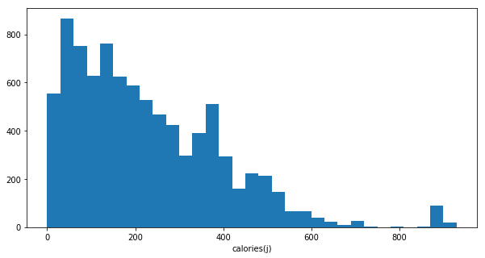

```python
# start with a standard-scaled plot
show_distribution('calories', 30, 'j')
```

> The distribution looks skweed to the right but we can observer several peaks, this implies that there are few groups of food smaples with quiet high calories ie above 400 , mean while most food samples have colories in the rage of 0 to 400

```python
nutrients_df['calories'].describe()
```

```
count    8789.000000
mean      226.283878
std       169.862001
min         0.000000
25%        91.000000
50%       191.000000
75%       337.000000
max       902.000000
Name: calories, dtype: float64
```

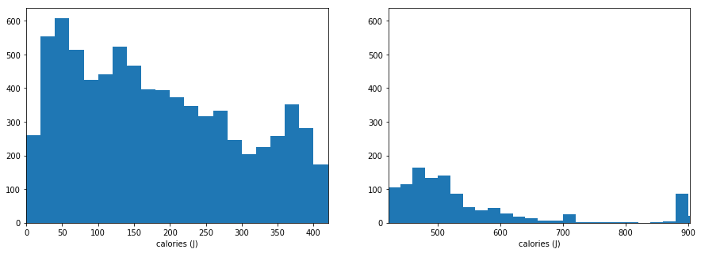

```python
# there's a seemingly long tail in the distribution, so we will try to set limits on the calories axis
binsize = 20
bins = np.arange(0, nutrients_df['calories'].max()+binsize, binsize)

plt.figure(figsize=[15, 5])
plt.subplot(1,2,1)
plt.hist(data = nutrients_df, x = 'calories', bins = bins)
plt.xlabel('calories (J)')
plt.xlim(0,420)

plt.subplot(1,2,2)
plt.hist(data = nutrients_df, x = 'calories', bins = bins)
plt.xlabel('calories (J)')
plt.xlim(421,903)

plt.show()
```

> The plots shows 03 distinct region samples with calories lower than 400, samples with calories between 400 andd 700 and samples around 900. however, the samples around 900 need more investigations as they seem aberantes.

> we will use the .agg method of the DataFrame to gain information about the mean, median, std, skewness to confirm that the data is really skweed before we can consider calories greater than 800 to be aberante statistical rule of thumbs is:
> - If the skewness is between -0.5 and 0.5, the data are fairly symmetrical
> - If the skewness is between -1 and — 0.5 or between 0.5 and 1, the data are moderately skewed
> - If the skewness is less than -1 or greater than 1, the data are highly skewed

```python
pd.set_option('display.max_columns', None)
nutrients_df.agg(['mean', 'median', 'std', 'skew']).calories
```

```
mean      226.283878
median    191.000000
std       169.862001
skew        1.149091
Name: calories, dtype: float64
```

> Turn out that our data is skewed, let explore what food is considered to be an outlier based on the Calories.
> - As our data is skewed enough, we would not rely on the mean to find the outlier; instead, we would apply the IQR method which is based on the median.
> - Interquartile Range is based on the data position.

```python
#we describe the ‘calories’ feature
nutrients_df['calories'].describe()
```

```
count    8789.000000
mean      226.283878
std       169.862001
min         0.000000
25%        91.000000
50%       191.000000
75%       337.000000
max       902.000000
Name: calories, dtype: float64
```

```python
#Specifying the limit
def get_outliers(feature):
    cal_Q1 = nutrients_df.describe()[feature]['25%']
    cal_Q3 = nutrients_df.describe()[feature]['75%']
    cal_IQR = cal_Q3 - cal_Q1
    return  nutrients_df[(nutrients_df[feature] < 1.5 * (cal_Q1 - cal_IQR)) | (nutrients_df[feature] > 1.5 * (cal_Q3 + cal_IQR)) ]['food_categories'].value_counts(ascending=True)
```

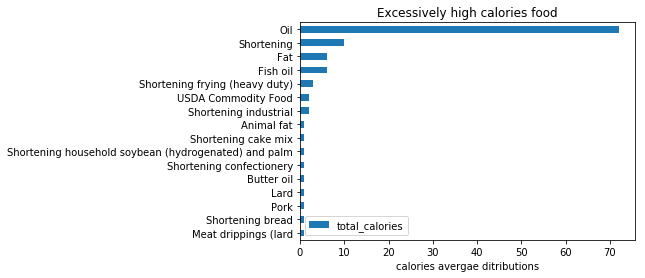

```python
#sb.countplot(y=outliers_based_onCalories.index, x=outliers_based_onCalories.values)
outliers_based_onCalories_df = pd.DataFrame(get_outliers('calories'))
outliers_based_onCalories_df.set_axis(['total_{}'.format('calories')], axis='columns', inplace=True)

## create figure
fig = plt.figure(figsize=[15, 10])
outliers_based_onCalories_df.plot.barh(color = sb.color_palette()[0])
plt.title('Excessively high calories food')
plt.xlabel('{} avergae ditributions'.format('calories'));
```

> Turn out, most of the high calories food category are those reach in oil, which is not surprising... the fact that tey are outliers is infact true but it reflect thier thier true nature in terms of calories and as such, we will leave them in our data.

## so how do protiens distribute in our sample foods

> protiens are our next variable that i suspect to have contributions to calories level let start by looking at thier distribution

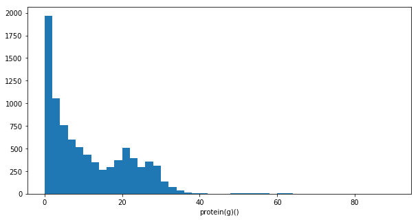

```python
show_distribution('protein(g)', 2,'')
```

> as usual, i prever to numerically evaluate the skewed nature of our graph, to determing whether it proper to use the mean to filter my samples

```python
pd.set_option('display.max_columns', None)
nutrients_df.agg(['mean', 'median', 'std', 'skew'])['protein(g)']
```

```
mean      11.345616
median     8.020000
std       10.530602
skew       1.165780
Name: protein(g), dtype: float64
```

> Taking into consideration our rules of thumbs, we can confidently say that our plot is skewed and as such since the skew value is more than 1 , it is preferable to extract outliers using the quatiles and than the mean.
- let proceed to extract and plot the outliers (foods with excessive proteins)

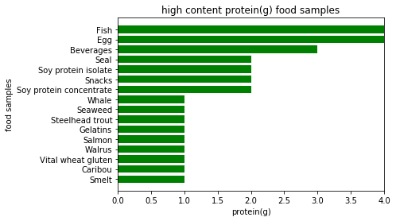

```python
# fisrt 20 samples with exceeding high fats
outliers_based_pro_df = pd.DataFrame(get_outliers('protein(g)'))
outliers_based_pro_df.reset_index(inplace=True)
x = list(outliers_based_pro_df['index'])
y = list(outliers_based_pro_df['food_categories'])
fig, ax = plt.subplots()
width = 0.75 # the width of the bars
ind = np.arange(len(y))  # the x locations for the groups
ax.barh(ind, y, width, color="green", align='edge')
ax.set_yticks(ind+width/2)
ax.set_yticklabels(x, minor=False)
#plt.xticks(np.arange(5),('Pre-clinical','Phase I','Phase II','Phase III', 'Approved'))
plt.margins(0,0.05)
plt.title('high content protein(g) food samples')
plt.ylabel('food samples')
plt.xlabel('protein(g)')
plt.show()
```

> Turn out, most of the high protein food category are Eggs, fish, soy, which is not surprising still. the fact that they are outliers is infact true but it reflect thier thier true nature in terms of proteins and as such, we will leave them in our data again.

## so how do fats distribute in our sample foods

> fats are our next variable that i suspect to have contributions to calories level let start by looking at thier distribution (here we will look at the total fats)

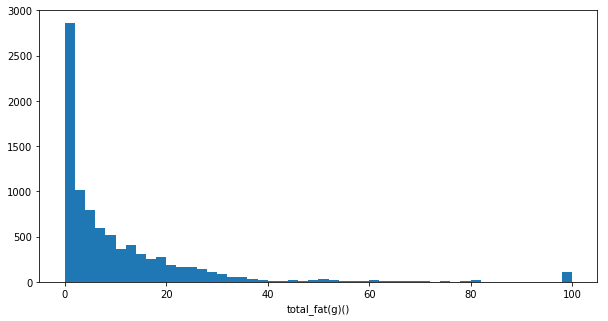

```python
show_distribution('total_fat(g)', 2,'')
```

> it seems the majority of samples of food are very low in total_fat (between 0 to around 40g) content and very few food samples have total_fat content greater than 40. and some foods are exceedindly in high total_fat worth investigation
> - we will continue investigation, but let fisrt confirm the skewed nature of these plot

```python
pd.set_option('display.max_columns', None)
nutrients_df.agg(['mean', 'median', 'std', 'skew'])['total_fat(g)']
```

```
mean      10.556855
median     5.100000
std       15.818247
skew       3.309571
Name: total_fat(g), dtype: float64
```

> The data is exceedingly skwed to the right.

> we will use the quatiles ranges to filter our those foods with exceedingly high total_fat

[figure not shown]

```python
#sb.countplot(y=outliers_based_onCalories.index, x=outliers_based_onCalories.values)
outliers_based_fats_df = pd.DataFrame(get_outliers('total_fat(g)'))
outliers_based_fats_df.set_axis(['{}'.format('total_fat(g)')], axis='columns', inplace=True)

## create figure
fig = plt.figure(figsize=[20, 10])
outliers_based_fats_df.plot.barh(color = sb.color_palette()[0])
plt.title('Excessively high total_fats food')
plt.xlabel('{} avergae ditributions'.format('total_fat(g)'));
```

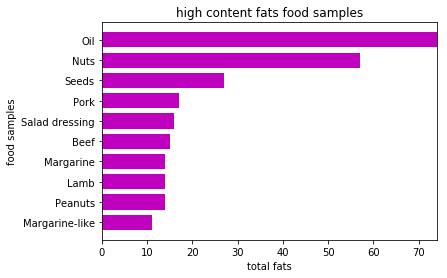

```python
# fisrt 20 samples with exceeding high fats
outliers_based_fats_df = pd.DataFrame(get_outliers('total_fat(g)')).tail(10)
outliers_based_fats_df.reset_index(inplace=True)
x = list(outliers_based_fats_df['index'])
y = list(outliers_based_fats_df['food_categories'])
fig, ax = plt.subplots()
width = 0.75 # the width of the bars
ind = np.arange(len(y))  # the x locations for the groups
ax.barh(ind, y, width, color="m", align='edge')
ax.set_yticks(ind+width/2)
ax.set_yticklabels(x, minor=False)
#plt.xticks(np.arange(5),('Pre-clinical','Phase I','Phase II','Phase III', 'Approved'))
plt.margins(0,0.05)
plt.xlabel('total fats')
plt.ylabel('food samples')
plt.title('high content fats food samples')
plt.show()
```

> As we likely suspected, most of these samples are oils and thier derivatives

## And how do carbohydates distribute in our sample foods

> carbohydates are our next variable that i suspect to have contributions to calories level let start by looking at thier distribution

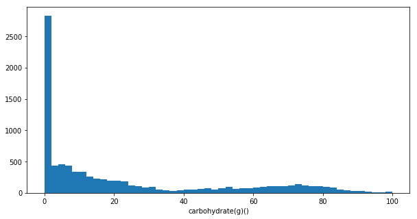

```python
show_distribution('carbohydrate(g)', 2,'')
```

> There seem to be 02 kinds of sample those with carbohydrate content lesser than 20 and some with carbohydrate between and 90 but again we have quit a high number of samples with very low carbohydrate

> let to set limit on the feature to eleminate the left tall tail so that other samples might appear

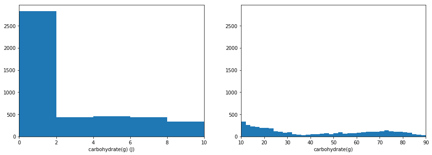

```python
binsize = 2
bins = np.arange(0, nutrients_df['carbohydrate(g)'].max()+binsize, binsize)

plt.figure(figsize=[15, 5])
plt.subplot(1,2,1)
plt.hist(data = nutrients_df, x = 'carbohydrate(g)', bins = bins)
plt.xlabel('carbohydrate(g) (J)')
plt.xlim(0,10)

plt.subplot(1,2,2)
plt.hist(data = nutrients_df, x = 'carbohydrate(g)', bins = bins)
plt.xlabel('carbohydrate(g)')
plt.xlim(10,90)

plt.show()
```

```python
pd.set_option('display.max_columns', None)
nutrients_df.agg(['mean', 'median', 'std', 'skew'])['carbohydrate(g)']
```

```
mean      22.121915
median     9.340000
std       27.266261
skew       1.127907
Name: carbohydrate(g), dtype: float64
```

> It confirms the skewedness of the distribution, let use the quatiles to get the extreme samples with exceedingly high carbohydrates

```python
#sb.countplot(y=outliers_based_onCalories.index, x=outliers_based_onCalories.values)
outliers_based_cabo_df = pd.DataFrame(get_outliers('carbohydrate(g)'))
outliers_based_cabo_df.set_axis(['{}'.format('carbohydrate(g)')], axis='columns', inplace=True)
outliers_based_cabo_df
## create figure
#fig = plt.figure(figsize=[20, 10])
#outliers_based_cabo_df.plot.barh(color = sb.color_palette()[0])
#plt.title('Excessively high carbohydrate food')
#plt.xlabel('{} avergae ditributions'.format('carbohydrate(g)'));
```

|  | carbohydrate(g) |
| --- | --- |

> well it appears we can not the outliers with our quatile range.

### Of the features you investigated, were there any unusual distributions? Did you perform any operations on the data to tidy, adjust, or change the form of the data? If so, why did you do this?

> > The features where largely skwewed to the right, and in other to reveail some data points , limits where applied to the axis,also, filting by quatiles ranges was done to get a better perception of the outliers

## How do carbohydrates, protiens and fats relate with calories

> we are going to do a pairplot to investigates the relationship between our major variable(calories) and the other features introduced above

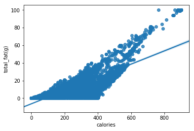

```python
## let start by investigating the relationship between calories and total fats
sb.regplot(data =nutrients_df,  x = nutrients_df['calories'], y = nutrients_df['total_fat(g)'])
```

The plot shows a strong relationship between calories and total_fat(g)

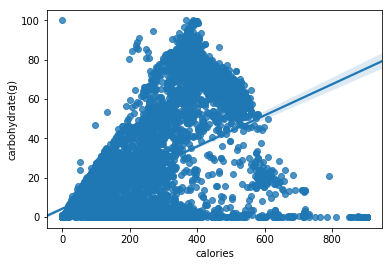

```python
## let  investigate the relationship between calories and total carbohydrates

sb.regplot(data =nutrients_df,  x = nutrients_df['calories'], y = nutrients_df['carbohydrate(g)'])
```

> the plot looks more of a positive correlation but further investigation is required

> we will reduce the number of food items using a random sample of the data to observer these distribution better

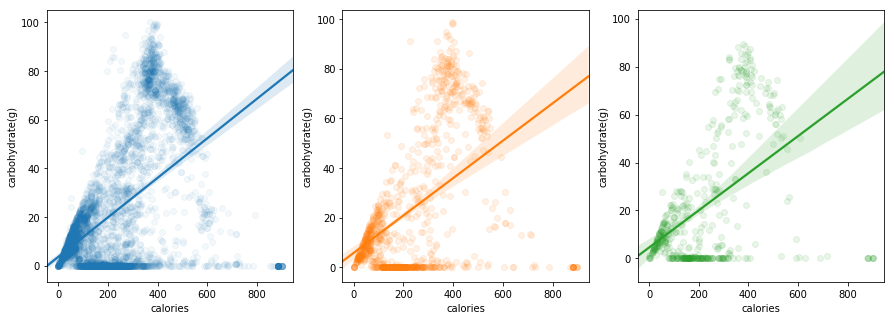

```python
#get a sample of sample
sample = nutrients_df.sample(5000)
fig, ax = plt.subplots(nrows=1, ncols=3,  figsize = [15,5])
default_color = sb.color_palette()[0]

sb.regplot(data=sample,  x = sample['calories'], y = sample['carbohydrate(g)'], ax=ax[0], truncate=False, x_jitter=0.3, scatter_kws={'alpha':1/20} )
##plot a new sample while adding some jitter and transparency
sample = nutrients_df.sample(1000)
sb.regplot(data = sample,  x = sample['calories'], y = sample['carbohydrate(g)'], ax=ax[1] , truncate=False, x_jitter=0.3, scatter_kws={'alpha':1/10})
##plot a new sample while adding some jitter and transparency
sample = nutrients_df.sample(500)
sb.regplot(data =sample,  x = sample['calories'], y = sample['carbohydrate(g)'], ax=ax[2], truncate=False, x_jitter=0.3, scatter_kws={'alpha':1/10})
plt.show()
```

> we have sample the data and a clearer relation is observered, the 02 features correlate but a much higher cobohydrate to very little change in colories

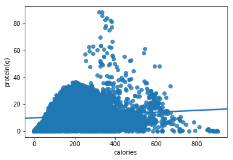

```python
## let  investigate the relationship between calories and total proteins

sb.regplot(data =nutrients_df,  x = nutrients_df['calories'], y = nutrients_df['protein(g)'])
```

> Well we can not assume much form this plot, again, let us take sample of the data

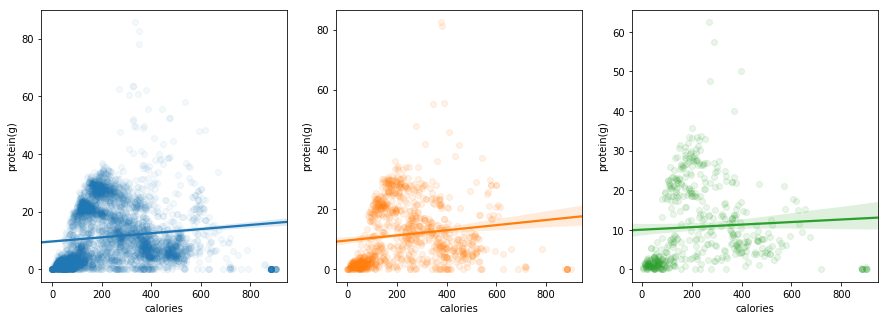

```python
#get a sample of sample
sample = nutrients_df.sample(5000)
fig, ax = plt.subplots(nrows=1, ncols=3,  figsize = [15,5])
default_color = sb.color_palette()[0]

sb.regplot(data=sample,  x = sample['calories'], y = sample['protein(g)'], ax=ax[0], truncate=False, x_jitter=0.3, scatter_kws={'alpha':1/20} )
##plot a new sample while adding some jitter and transparency
sample = nutrients_df.sample(1000)
sb.regplot(data = sample,  x = sample['calories'], y = sample['protein(g)'], ax=ax[1] , truncate=False, x_jitter=0.3, scatter_kws={'alpha':1/10})
##plot a new sample while adding some jitter and transparency
sample = nutrients_df.sample(500)
sb.regplot(data =sample,  x = sample['calories'], y = sample['protein(g)'], ax=ax[2], truncate=False, x_jitter=0.3, scatter_kws={'alpha':1/10})
plt.show()
```

> Generally, the relationship is a positive correlation, but we can not predict one point using the other easily., we also see the presence of some outliers.

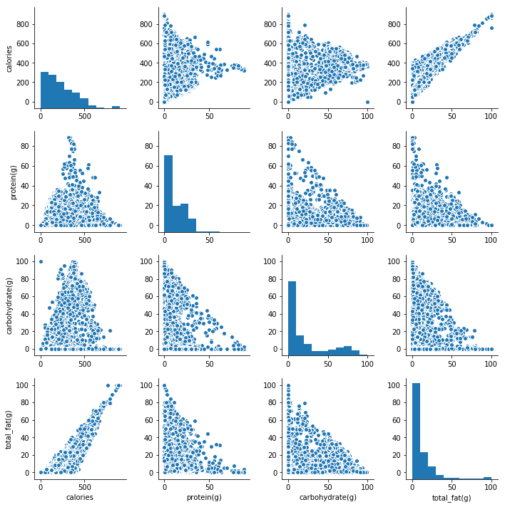

```python
#let us investigate all interrelationship
#we slice the dataframe and make a pairplot
features =['calories', 'protein(g)' , 'carbohydrate(g)','total_fat(g)']
sb.pairplot(nutrients_df[features])
```

> we can see a good relation ship between calories and fats, smaller relationship between proteins, cabohydrate and calories there simple to be negative correlations between the features like protein and fats, protein and carbohydrates,cabohydrate and fats..which requires further investigation.

> le us observe this relationships and thier correlation factors with a heat map

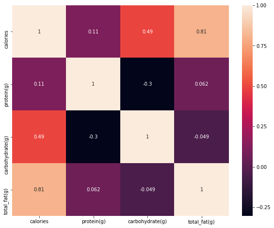

```python
fig = plt.figure(figsize=[10,8])
sb.heatmap(nutrients_df[features].corr(), annot =True)
```

> as we predited, there is a negative correlation between proteins and carbohydrates , cabohydrates and fats, but however, the relation protein and fats not as we predited, there exist a little correlation between protein and fats

## could there be a relationship between fats and and proteins

> let us examin the protein and fat relation further by ploting these 02 features only

```
Text(0,0.5,'total_fat(g)')
```

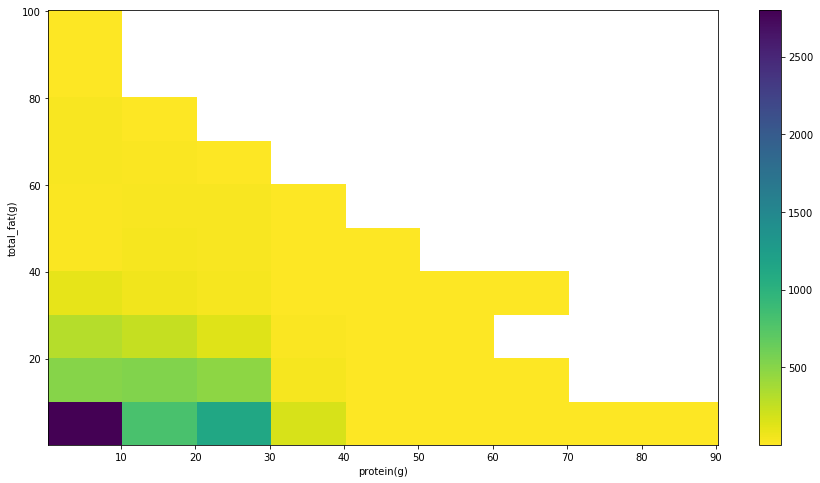

```python
## let plot 02D plot of protien vs fats to investigate thier relation further
fig = plt.figure(figsize=[15,8])
bins_x = np.arange(0.2, nutrients_df['protein(g)'].max()+2, 10)
bins_y = np.arange(0.2, nutrients_df['total_fat(g)'].max()+2, 10)
plt.hist2d(data = nutrients_df, x = 'protein(g)', y = 'total_fat(g)', bins = [bins_x, bins_y], cmap = 'viridis_r', cmin = 0.5)
plt.colorbar()
plt.xlabel('protein(g)')
plt.ylabel('total_fat(g)')
```

> yes a relation esist but a week very week one

### Talk about some of the relationships you observed in this part of the investigation. How did the feature(s) of interest vary with other features in the dataset?

> After our exploration we have noted a strong correlation between fats and calories, and a non negleted relationship between proteins, carbohydrates with colories.

### Did you observe any interesting relationships between the other features (not the main feature(s) of interest)?

> interesting, we observed that, there is a negative correlation between proteins and carbohydrates , cabohydrates and fats, but however, the relation protein and fats were not as we predited, there exist a little correlation between protein and fats that requires some investigations

## Multivariate Exploration

```
Text(0,0.5,'calories')
```

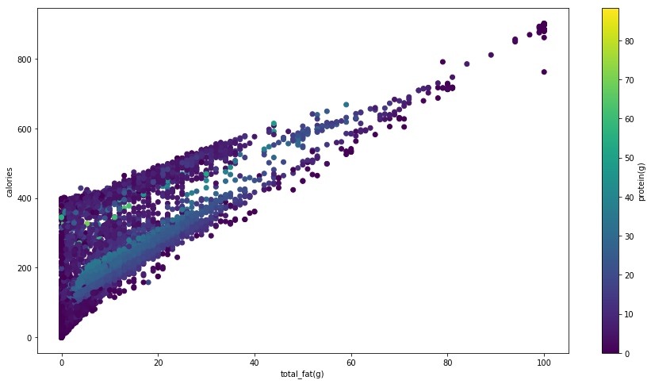

```python
# plot the fat, calories nd protein , remember that protein showed a positve relation with fats and calories
fig = plt.figure(figsize=[15,8])
plt.scatter(data = nutrients_df, x = 'total_fat(g)', y = 'calories', c = 'protein(g)')
plt.colorbar(label='protein(g)')
plt.xlabel('total_fat(g)')
plt.ylabel('calories')
```

> As before, the calories content goes up with fats but protiens seem to increase only moderately, and that is to be espected, with high quantity of protein where fats concertation are a little

### how do fats , relate with carbohydrates on proteins

```
Text(0,0.5,'carbohydrate(g)')
```

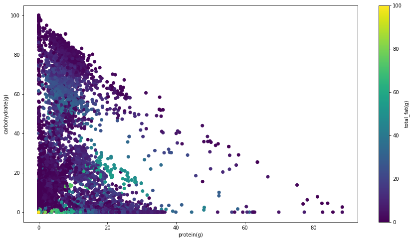

```python
## let plot proteins, carbohydrates and fats to see their relation
fig = plt.figure(figsize=[15,8])
plt.scatter(data = nutrients_df, x = 'protein(g)', y = 'carbohydrate(g)', c = 'total_fat(g)')
plt.colorbar(label='total_fat(g)')
plt.xlabel('protein(g)')
plt.ylabel('carbohydrate(g)')
```

> we see that, the fats is in high amount when carbohydrates and proteins are lower, and seem not to exist when carbohydrates and proteins are very high, also. we see a never relation between protein and carbohydrates just like we showed earlier

### how do fats , relate with carbohydrates on calories

```
Text(0,0.5,'calories')
```

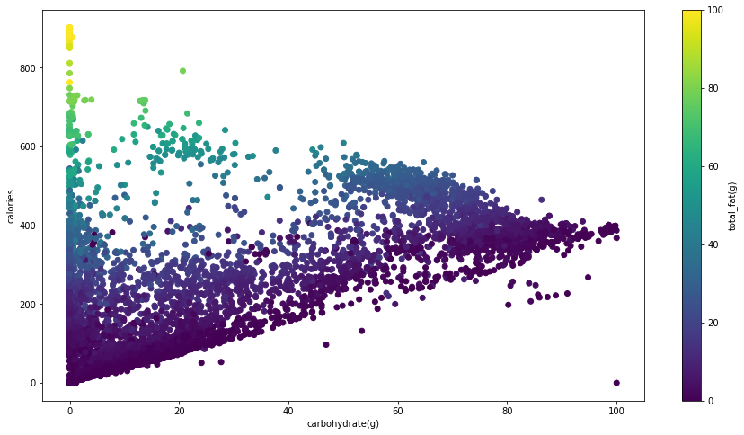

```python
fig = plt.figure(figsize=[15,8])
plt.scatter(data = nutrients_df, x = 'carbohydrate(g)', y = 'calories', c = 'total_fat(g)')
plt.colorbar(label='total_fat(g)')
plt.xlabel('carbohydrate(g)')
plt.ylabel('calories')
```

> its clear that, fats exist when only carbohydrates are lower and they have a very positive correlation with calories

## how do our 03 variables relate with calories

> this further analysis is just mean to summarise our results

> And the best way of summarising this is to pivot our 03 features to produce a category variable

```python
##let us melt the variables barbihydrates, proteins, and fats into a categorial variable

nutrients_mlt = nutrients_df.melt(id_vars = 'calories', value_vars=['carbohydrate(g)','total_fat(g)','protein(g)'], var_name='mojor_nutrient', value_name='quantity')
nutrients_mlt
```

|  | calories | mojor_nutrient | quantity |
| --- | --- | --- | --- |
| 0 | 381 | carbohydrate(g) | 91.27 |
| 1 | 691 | carbohydrate(g) | 13.86 |
| 2 | 25 | carbohydrate(g) | 5.88 |
| 3 | 367 | carbohydrate(g) | 73.13 |
| 4 | 144 | carbohydrate(g) | 30.40 |
| 5 | 25 | carbohydrate(g) | 4.97 |
| 6 | 42 | carbohydrate(g) | 6.70 |
| 7 | 282 | carbohydrate(g) | 0.00 |
| 8 | 300 | carbohydrate(g) | 0.46 |
| 9 | 290 | carbohydrate(g) | 9.00 |
| 10 | 25 | carbohydrate(g) | 6.25 |
| 11 | 349 | carbohydrate(g) | 77.06 |
| 12 | 51 | carbohydrate(g) | 13.12 |
| 13 | 407 | carbohydrate(g) | 72.30 |
| 14 | 215 | carbohydrate(g) | 0.20 |
| 15 | 134 | carbohydrate(g) | 0.00 |
| 16 | 316 | carbohydrate(g) | 42.60 |
| 17 | 29 | carbohydrate(g) | 6.50 |
| 18 | 148 | carbohydrate(g) | 28.10 |
| 19 | 172 | carbohydrate(g) | 1.55 |
| 20 | 57 | carbohydrate(g) | 13.93 |
| 21 | 182 | carbohydrate(g) | 37.60 |
| 22 | 272 | carbohydrate(g) | 68.73 |
| 23 | 516 | carbohydrate(g) | 50.30 |
| 24 | 201 | carbohydrate(g) | 8.13 |
| 25 | 25 | carbohydrate(g) | 6.25 |
| 26 | 270 | carbohydrate(g) | 67.38 |
| 27 | 119 | carbohydrate(g) | 0.00 |
| 28 | 268 | carbohydrate(g) | 94.80 |
| 29 | 673 | carbohydrate(g) | 13.08 |
| ... | ... | ... | ... |
| 26337 | 267 | protein(g) | 25.03 |
| 26338 | 206 | protein(g) | 18.74 |
| 26339 | 714 | protein(g) | 1.90 |
| 26340 | 205 | protein(g) | 34.46 |
| 26341 | 163 | protein(g) | 29.59 |
| 26342 | 47 | protein(g) | 0.14 |
| 26343 | 224 | protein(g) | 30.70 |
| 26344 | 179 | protein(g) | 27.56 |
| 26345 | 64 | protein(g) | 1.78 |
| 26346 | 201 | protein(g) | 30.63 |
| 26347 | 175 | protein(g) | 28.60 |
| 26348 | 68 | protein(g) | 1.48 |
| 26349 | 128 | protein(g) | 3.20 |
| 26350 | 445 | protein(g) | 8.81 |
| 26351 | 135 | protein(g) | 23.30 |
| 26352 | 149 | protein(g) | 22.93 |
| 26353 | 133 | protein(g) | 22.66 |
| 26354 | 159 | protein(g) | 25.90 |
| 26355 | 352 | protein(g) | 22.26 |
| 26356 | 365 | protein(g) | 22.60 |
| 26357 | 289 | protein(g) | 28.82 |
| 26358 | 148 | protein(g) | 22.55 |
| 26359 | 161 | protein(g) | 21.62 |
| 26360 | 884 | protein(g) | 0.00 |
| 26361 | 124 | protein(g) | 23.49 |
| 26362 | 125 | protein(g) | 23.45 |
| 26363 | 206 | protein(g) | 29.59 |
| 26364 | 277 | protein(g) | 16.74 |
| 26365 | 121 | protein(g) | 23.37 |
| 26366 | 121 | protein(g) | 23.37 |

26367 rows × 3 columns

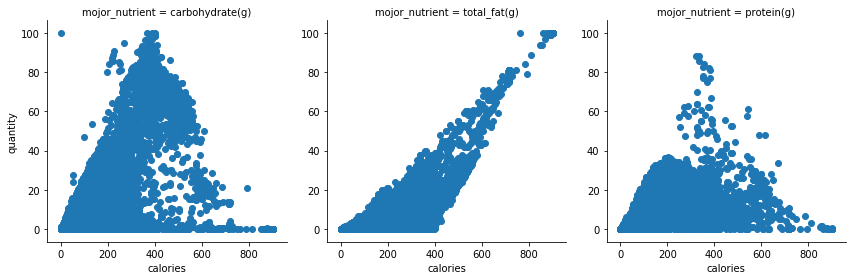

```python
## using a facetGrid let plot our 03 variables againt thier contributions to calories
g = sb.FacetGrid(data = nutrients_mlt, col = 'mojor_nutrient', size = 4)
g.map(plt.scatter, 'calories', 'quantity')
```

> - just as before, calories level increase only seemingly with carbohydrates
> - calories levels increase steeply with total fats
> - calories level also increase seemingly with calories but not as carbohydrates

### Talk about some of the relationships you observed in this part of the investigation. Were there features that strengthened each other in terms of looking at your feature(s) of interest?

> carbohydrate and fats relationship seem to have strengthen each other with respect to calories content , an to me that is to be espected

### Were there any interesting or surprising interactions between features?

> but the nature of the relation with fats and calories makes fats the ultimate sourcce of calories